# Crimes in Mexico - A shiny app

Last Presidential term (2006-2012) in Mexico was characterized for the violence generated by the war against drug cartels. The current president belongs to a different party and he claimed that his security strategy would be more effective.

An application in `shiny` was done in order to make the crimes at different times easier to compare. It allows to compare not only the mentiones periods, but any dates between 1997 and the present.

The idea of this work arose from the webpage http://crimenmexico.diegovalle.net/en/ by [Diego Valle Jones](http://www.diegovalle.net), who has very interesting plots and crimes data from Mexico from has some illustrative plots of a subset of crimes-related variables from the Mexican government website [Secretariado Ejecutivo del Sistema Nacional de Seguridad Pública](http://www.secretariadoejecutivo.gob.mx/es/SecretariadoEjecutivo/Incidencia_Delictiva).

I use the same data as Diego Valle Jones. Those are number of crimes that every state submits each month.

In the first section, I describe with more detail what is the database about. Then I explain the difficulties of obtainin the database, then the processing. Finally, I describe the `shiny` app.

## Description of the database

According to the Federal Attorney General of Mexico, crimes fall within the common or federal law. Federal crimes are those that affect the health, the economy or the security of the country. Common law crimes are those that affect people directly.

The database contains all the counts for the different categories every month from 1997-01 to 2014-03. There data is available for each of the 32 states of Mexico.

## Database and problems

In this part I describe what I did in order to obtain the databases that I use for the `shiny` app. I end up with two databases: national crimes and statewise crimes.

The original data is available at the website of [Secretariado Ejecutivo del Sistema Nacional de Seguridad Pública](http://www.secretariadoejecutivo.gob.mx/es/SecretariadoEjecutivo/Incidencia_Delictiva). It displays the following menu (it is in Spanish, but most of the words are cognates):

[figure not shown]

If the first option is selected, *Herramientas de Análisis* (Analysis tools), you can create plots for the features and also download the data you are plotting, however, it never works well. The next image is a screenshot the site.

[figure not shown]

If you select the option *Exportación de Información* (Exporting information), you can download the features that you want directly in a `csv` file. My idea was to try to do this automatically from `R`, but it never worked for me, not even manually. The following image shows that menu:

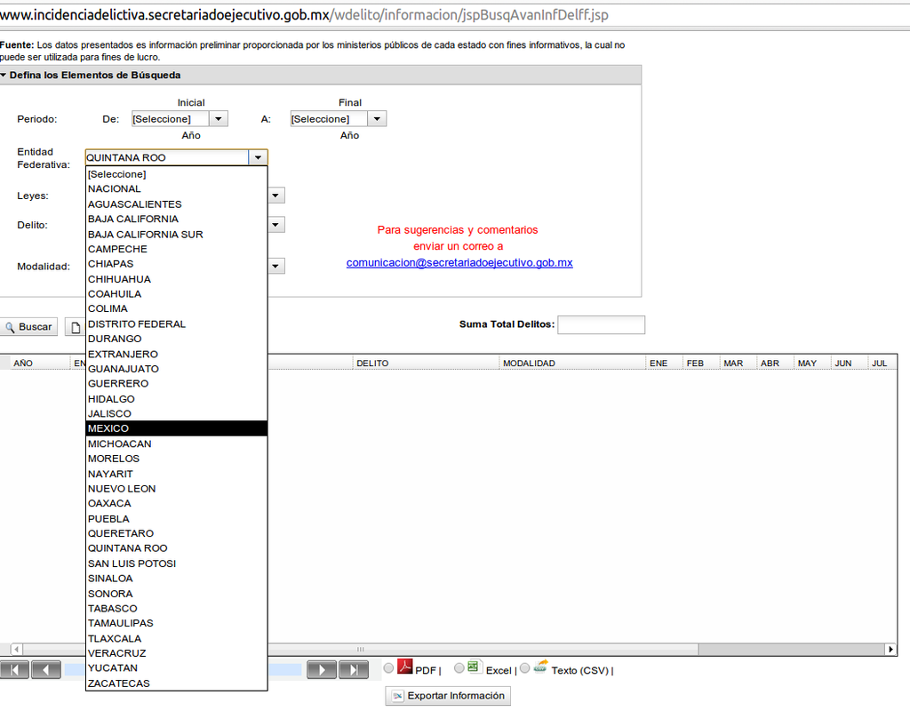

Finally, you can also download the tables in `pdf` files. I found a package in R that could help to obtain the information from tables in `pdf`, however, not all the information is available in `pdf`.

I sent an email message to Diego Valle. He told me that he decided to create those plots precisely because the [government webpage](http://www.secretariadoejecutivo.gob.mx/es/SecretariadoEjecutivo/Incidencia_Delictiva) never works. He send me his code in `Python` and he highlighted that he is constantly checking for new information and he extracts very little pieces of information since the wepages crashes otherwise.

I decided then to use the data directly from [Diego Valle's website](http://crimenmexico.diegovalle.net/en/csv/).

## Processing the data

I will decribe piece by piece what I have done. First of all, this is the packages that will be used to process the data.

```r
suppressPackageStartupMessages(library("maptools"))
```

```
## Error: there is no package called 'maptools'
```

```r
suppressPackageStartupMessages(library("ggplot2"))
```

```
## Error: there is no package called 'ggplot2'
```

```r
suppressPackageStartupMessages(library("plyr"))
```

```
## Error: there is no package called 'plyr'
```

```r
suppressPackageStartupMessages(library("dplyr"))
```

```
## Error: there is no package called 'dplyr'
```

```r
suppressPackageStartupMessages(library("lubridate"))
```

```
## Error: there is no package called 'lubridate'
```

```r
suppressPackageStartupMessages(library("car"))
```

```
## Error: there is no package called 'car'
```

```r
suppressPackageStartupMessages(library("R.utils"))  # To create gz
```

The first thing to do is to is to make all the data consistet. As I said before, there are two major categories of crimes: Common and Federal, and there is a file for each one. Both have different levels of crimes, category, type and subtype. I am going to keep the law, crime and category. Then I merge them.

On the other hand, I also translate the names to English and create the date column.

```r
# ### Download directly. It takes a lot of time
# ### Do not run!
# federal.link <- "http://crimenmexico.diegovalle.net/en/csv/fuero-federal-estados.csv.gz"
# common.link <- "http://crimenmexico.diegovalle.net/en/csv/fuero-comun-estados.csv.gz"
# con <- gzcon(url(federal.link))
# txt <- readLines(con)
# dat <- read.csv(textConnection(txt))

### Reading data.
common <- read.csv(gzfile("./data/fuero-comun-estados.csv.gz")) %.% tbl_df() #Common
```

```
## Error: could not find function "%.%"
```

```r
federal <- read.csv(gzfile("./data/fuero-federal-estados.csv.gz")) %.% tbl_df() #Federal
```

```
## Error: could not find function "%.%"
```

```r
## Common: crime
sp.names <- common$crime %.% unique() %.% as.character() ## Spanish names
```

```
## Error: could not find function "%.%"
```

```r
en.names <- c("Property_crimes", ## English names
              "Sexual_crimes",
              "Homicides",
              "Injuries",
              "Other_crimes",
              "Kidnapping",
              "Robbery")
string <- paste0("sp.names[", 1:length(sp.names), "] = ",
                 "en.names[", 1:length(sp.names), "]", collapse = '; ')
```

```
## Error: object 'sp.names' not found
```

```r
common$crime <- recode(common$crime, string)
```

```
## Error: could not find function "recode"
```

```r
## Common: category
sp.names <- common$category %.% unique() %.% as.character() ## Spanish names
```

```
## Error: could not find function "%.%"
```

```r
en.names <- c("Property_crimes", ## English names
              "Sexual_crimes_(violation)",
              "Homicides",
              "Injuries",
              "Other_crimes",
              "Kidnapping",
              "Common_robbery",
              "Rustling",
              "Highway_robbery",
              "Bank_robbery")
string <- paste0("sp.names[", 1:length(sp.names), "] = ",
                 "en.names[", 1:length(sp.names), "]", collapse = '; ')
```

```
## Error: object 'sp.names' not found
```

```r
common$category <- recode(common$category, string)
```

```
## Error: could not find function "recode"
```

```r
# ## Common: type
# sp.names <- common$type %.% unique() %.% as.character() ## Spanish names
# en.names <- c("Breach_of_trust",
#               "Property_crimes", ## English names
#               "Offense_of_dispossession",
#               "Extortion",
#               "Fraud",
#               "Sexual_crimes_(violation)",
#               "Guilty",
#               "By_negligence",
#               "Guilty",
#               "By_negligence",
#               "Threats",
#               "Staturory_rape",
#               "Other_sexual",
#               "Other_crimes",
#               "Kidnapping",
#               "With_violence",
#               "Without_violence",
#               "Rustling")
# string <- paste0("sp.names[", 1:length(sp.names), "] = ",
#                  "en.names[", 1:length(sp.names), "]", collapse = '; ')
# common$type <- recode(common$type, string)

## Delete type and sub-type
common <- common[, -(6:7)]
```

```
## Error: object 'common' not found
```

```r
## Federal: crime
sp.names <- federal$crime %.% unique() %.% as.character() ## Spanish names
```

```
## Error: could not find function "%.%"
```

```r
en.names <- c("Against_health",
              "Other_crimes",
              "Historical_information",
              "Federal_Act_against_organized_crime",
              "General_health_Act",
              "Other_laws")
string <- paste0("sp.names[", 1:length(sp.names), "] = ",
                 "en.names[", 1:length(sp.names), "]", collapse = '; ')
```

```
## Error: object 'sp.names' not found
```

```r
federal$crime <- recode(federal$crime, string)
```

```
## Error: could not find function "recode"
```

```r
## Federal: category
sp.names <- federal$category %.% unique() %.% as.character() ## Spanish names
```

```
## Error: could not find function "%.%"
```

```r
en.names <- c("Trade",
              "Other",
              "Possession",
              "Production",
              "Supply",
              "Traffic",
              "Transportation",
              "AVGC(1997-2011)",
              "Against_public_official",
              "Against_the_environment", #10
              "Against_body",
              "Electoral",
              "Copyrights",
              "Counterfeiting",
              "Other",
              "Other",
              "Property",
              "Copyrights",
              "Roads",
              "Criminal_association(1997-2011)", #20
              "Vehicle_transportation(1999-2007)",
              "Highway_robbery",
              "Against_health",
              "LFCDO(2001-2011)",
              "Other",
              "Drug_dealing",
              "Other",
              "Federal_tax_code",
              "Industrial_property",
              "Migration", #30
              "Roads",
              "Federal_firearms_and_explosives",
              "Copyrights",
              "Law_of_credit_and_insurance",
              "Other",
              "Other"
              )
string <- paste0("sp.names[", 1:length(sp.names), "] = ",
                 "en.names[", 1:length(sp.names), "]", collapse = '; ')
```

```
## Error: object 'sp.names' not found
```

```r
federal$category <- recode(federal$category, string)
```

```
## Error: could not find function "recode"
```

```r
## Get rid of Law
federal <- federal[, -4]
```

```
## Error: object 'federal' not found
```

```r
## Adding common or Federal
common$law <- "common"
```

```
## Error: object 'common' not found
```

```r
federal$law <- "Federal"
```

```
## Error: object 'federal' not found
```

```r
## Merging data-sets
data <- rbind(common, federal)
```

```
## Error: object 'common' not found
```

```r
## Deleting variables
rm(common, federal, en.names, sp.names, string)
##
data <- data %.%
  mutate(date = ymd(paste(year, month, "01", sep = "-"))) %.% # Adding date
  group_by(year, month, crime, category, date)
```

```
## Error: could not find function "%.%"
```

Each presidential term lasts six years. We have to associate with each date the days that the corresponding president has ruled the country and the political party.

On the other hand, we also have to correct the state codes, since there are states with the wrong labels. Since the Spanish diccionary does not longer consider the *ch* combination as a letter, so the alphabetical order of the states is slightly different.

```r
### This is the first day of government period for recorded data, i.e., We
### have data starting on 1997. That president started his period on
### 1994-12-01
day0 <- ymd("1994-12-01")
```

```
## Error: could not find function "ymd"
```

```r
## Now we add days of government and period of government.
aux <- function(date) {
    ## Aux function to determine the period.  Receives date type argument
    val <- ifelse(date < day0 + years(6), 0, ifelse(date < day0 + years(2 *
        6), 1, ifelse(date < day0 + years(3 * 6), 2, 3)))
    return(val)
}

data <- group_by(data, law) %.% mutate(period.code = aux(date), days = as.numeric(date -
    years(period.code * 6) - day0), party = c("PAN", "PRI")[((period.code ==
    0) | (period.code == 3)) + 1]) %.% group_by(period.code, days, party, law)
```

```
## Error: could not find function "%.%"
```

```r
rm(aux)

## We also have to add the right state code, it is wrong beacuse the 'ch' is
## no longer considered 'letter' in the Spanish diccitionary
aux <- function(code) {
    code[(code == 5) | (code == 6)] <- -1 * (code[(code == 5) | (code == 6)] +
        2)
    code[(code == 7) | (code == 8)] <- code[(code == 7) | (code == 8)] - 2
    code[code < 0] <- -code[code < 0]

    return(code)
}
data <- mutate(data, state_code = aux(state_code))
```

```
## Error: could not find function "mutate"
```

```r
rm(aux)
```

Finally, we create the tables by states and national summarising different crime types. I am also adding the period (displayed as date). Save tables after that in csv.gz format.

```r
## Presitential terms
per <- paste0(1994 + 6 * (0:3), "-12-01 to ", 2000 + 6 * (0:3), "-11-30")

## Add column with Presidential terms
data <- mutate(data, period = paste0(period.code + 1, ". ", per[period.code +
    1])) %.% group_by(period)
```

```
## Error: could not find function "%.%"
```

```r
rm(per)

## Creating table by states and adding
state.wise <- group_by(data, state_code, population) %.% summarise(total = sum(count,
    na.rm = T)) %.% mutate(total.rate = 10000 * total/population)
```

```
## Error: could not find function "%.%"
```

```r
## Same for the whole country
national <- summarise(data, total = sum(count, na.rm = T), population = sum(unique(population)),
    total.rate = 10000 * total/population)
```

```
## Error: could not find function "summarise"
```

```r
## Write and compress
write.csv(state.wise, file = "./data/states.csv")
```

```
## Error: object 'state.wise' not found
```

```r
write.csv(national, file = "./data/national.csv")
```

```
## Error: object 'national' not found
```

```r
gzip("./data/national.csv")
```

```
## Error: No such file: ./data/national.csv
```

```r
gzip("./data/states.csv")
```

```
## Error: No such file: ./data/states.csv
```

I generate a map in the `shiny` app for comparing crimes. The following is the code used to extract the polygons, then I saved the data frame. The original resolution was too high, I correct that. Do NOT run the next code.

I also add the the names of the states in this part.

```r
##### Extracting polygons and saving data.frame, so it will not be run again.
xx <- readShapeSpatial("../mexico/MEX_adm1.shp")
xxx <- thinnedSpatialPoly(as(xx, "SpatialPolygons"), tolerance = 0.1, minarea = 0.0005,
                          topologyPreserve = TRUE)
extractPolygons <- function(shapes) {
  require(plyr)

  dframe <- ldply(1:length(shapes@polygons), function(i) {
    ob <- shapes@polygons[[i]]@Polygons
    dframe <- ldply(1:length(ob), function(j) {
      x <- ob[[j]]
      co <- x@coords
      data.frame(co, order = 1:nrow(co), group = j)
    })
    dframe$region <- i
    dframe
  })
  # construct a group variable from both group and polygon:
  dframe$group <- interaction(dframe$region, dframe$group)

  dframe
}
mex <- extractPolygons(xxx)

state.name <- c("Aguascalientes", "Baja California",
                "Baja California Sur", "Campeche", "Chiapas", #5
                "Chihuahua", "Coahuila", "Colima",
                "Distrito Federal", "Durango", #10
                "Guanajuato", "Guerrero", "Hidalgo",
                "Jalisco", "Estado de México", #15
                "Michoacán", "Morelos", "Nayarit",
                "Nuevo León", "Oaxaca", #20
                "Puebla", "Querétaro", "Quintana Roo",
                "San Luis Potosí", "Sinaloa", #25
                "Sonora", "Tabasco", "Tamaulipas",
                "Tlaxcala", "Veracruz",
                "Yucatán", "Zacatecas"
                )

mex <- mutate(mex, state.name = state.name[region])
write.csv(mex, "./mexico/polygons.csv")
```

## Shiny app

The following image is what shows up when we run the app. For all the options, we select the law, then it displays the possible options for crime under that law, and finally, the appropriate category. We can also select the range where we want to make a comparison.

The first plot shows the path for the specified range. It shows the color according to the Presidential term and type of line according to the political party.

[figure not shown]

The second tab shows the difference in the rate of the specified crime for the specified range (it takes the extremes) for each state.

[figure not shown]

The following plot shows two maps of Mexico, for the beginning and the end of the selected period. The darker color of the state, the more incidence of that crime it has.

[figure not shown]

Finally, we display the first elemements of the table for national crimes, this is just to show the structure of the data.

[figure not shown]